# TP2 - Econometrics

### 8. Quality check : Explain the type of quality check we have to run to derive a robust conclusion regarding the estimated specification. Run the required quality checks seen during the class. Comment your results

On commence par effectuer un test de Ljung-Box pour tester la dépendance du modèle :

```r
Ljung_box <- Box.test(MGR, lag = 20, type = "Ljung-Box")
Ljung_box
```

```
##
##  Box-Ljung test
##
## data:  MGR
## X-squared = 714.14, df = 20, p-value < 2.2e-16
```

> On constate que la p-value du test est inférieure à 0.05 et même 0.01. On peut alors affirmer avec un niveau de confiance de 99% que le modèle est autocorrélé.

Par la suite :

On considère la RMSE pour estimer l’errreur quadratique moyenne du modèle pour tester la précision de ce dernier.

```r
RMSE <- function(observed,predicted)
{
  rmse <- sqrt(mean((observed-predicted)^2))
  rmse
}
Rmse <- RMSE(MGR,estimated_MGR)
Rmse # 0.003019579
```

```
## [1] 0.003019579
```

> On obtient une erreur quadratique moyenne de l’ordre de 10^-3, ce qui vient confirmer les hypothèses effectuées. Le modèle est précis comme on a pu l’observer sur le graphique de comparaison précedemment.

### 9. Forecasting : We want to forecast the PPI on a monthly basis, over the next three months. Use the required R function available in R to produce the values yt+1,yt+2 and yt+3.

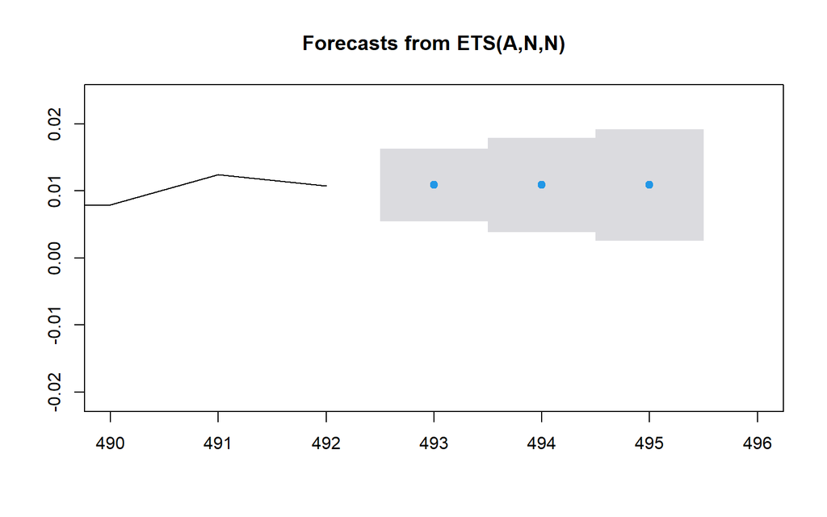

```r
fc <- forecast(estimated_MGR, level = c(95), h = 3)
plot(fc,type= "l", xlim =c(490,496))
```

> En observant les prédictions, on constate qu’elles sont cohérentes par rapport à la représentation graphique. Si on compare le graphique initiale et les prédictions, on constate que les prédictions s’inscrivent dans une continuité cohérente par rapport aux données.

## Exercise 4 : The US stock market

We consider the s&p500 price index. After calculating the monthly returns of stock index, over the whole period, analyze its behavior using the questions of the third exercise.

### 1. Load the s&p500 data from your workspace. Convert and plot the time series. Can the producer prices index be modeled without any transformation ? Explain.

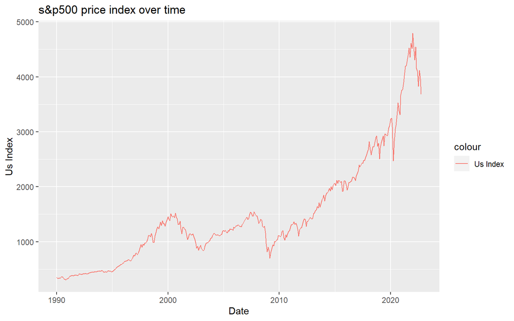

```r
Stockdata <- read.csv("us_stock_data.csv" ,header = TRUE, sep = ",")
Stockdata$Date <- as.Date(Stockdata$Date, format = "%m/%d/%Y")

ggplot(Stockdata,aes(x = Stockdata$Date, y = Stockdata$usindex, col = "Us Index")) + geom_line() + xlab("Date") + ylab("Us Index") + ggtitle("s&p500 price index over time")
```

> On constate une croissance du prix s&p500 au cours du temps.

On peut également convertir le dataset en série temporelle :

```r
Stockdata.ts=ts(data=Stockdata$usindex, start=c(1990,1, 1), end=c(2022, 10, 1), frequency = 12)
head(Stockdata.ts, n = 24)
```

```
##         Jan    Feb    Mar    Apr    May    Jun    Jul    Aug    Sep    Oct
## 1990 353.40 328.79 332.74 338.70 332.25 363.16 359.54 355.52 322.56 314.94
## 1991 330.22 343.05 370.47 371.30 380.29 388.06 377.92 387.12 395.43 389.20
##         Nov    Dec
## 1990 307.02 324.10
## 1991 391.32 381.40
```

### 2. Calculate the monthly growth rate of the Stockdata between January 1981 and December 2021. Can the Stockdata inflation be modeled now with an ARMA(p,q) ?

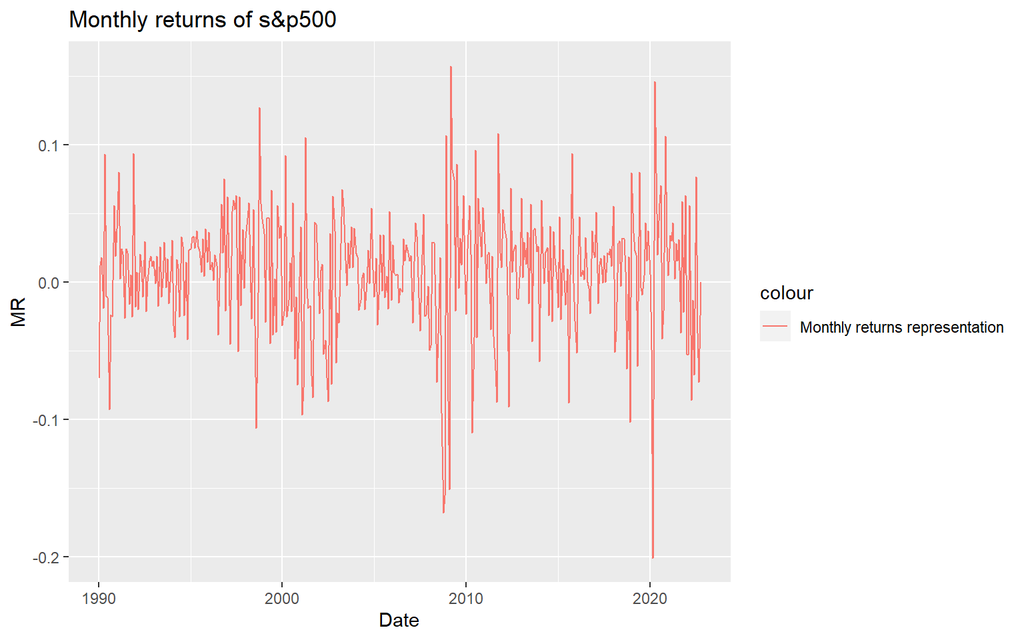

```r
Monthly_gr_usindex <- data.frame(Date = Stockdata$Date, MR = 0*Stockdata$usindex)
for (i in 0:393){
  Monthly_gr_usindex$MR[i] <- (Stockdata$usindex[i+1] - Stockdata$usindex[i])/Stockdata$usindex[i]
}
MR_plot <- ggplot(Monthly_gr_usindex, aes(x = Monthly_gr_usindex$Date, y = Monthly_gr_usindex$MR, col = "Monthly returns representation"))  + geom_line() + xlab("Date") + ylab("MR") + ggtitle("Monthly returns of s&p500")
MR_plot
```

> On observe une allure stationnaire sur le graphique, il est alors possible de considérer le modèle ARMA(p,q) pour faire des prédictions.

### 3. Identification : Use the ACF and the PACF to identify the most appropriate lags to model this inflation rate. We want to confront the previous result by calculating the information criteria.

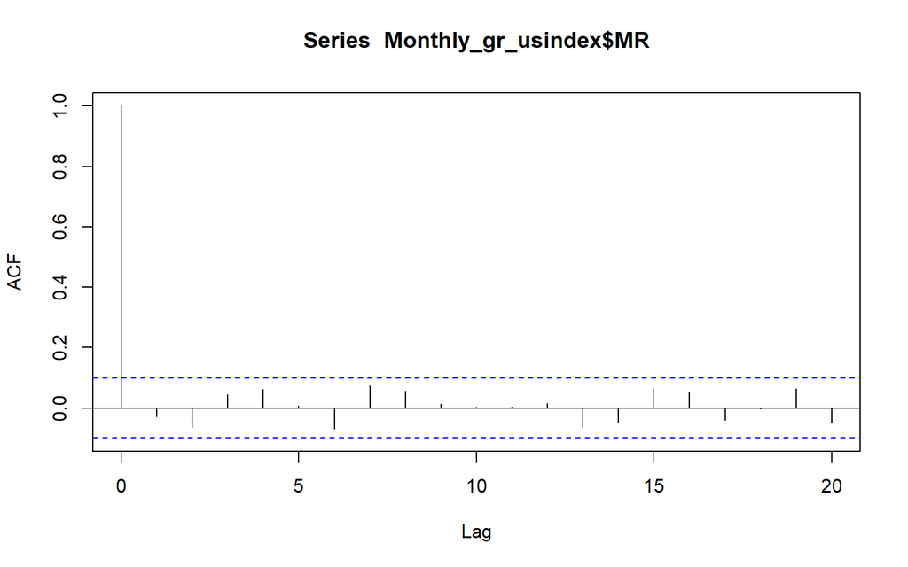

```r
autocorrelation_MR <- acf(Monthly_gr_usindex$MR, lag = 20, type = "correlation")
```

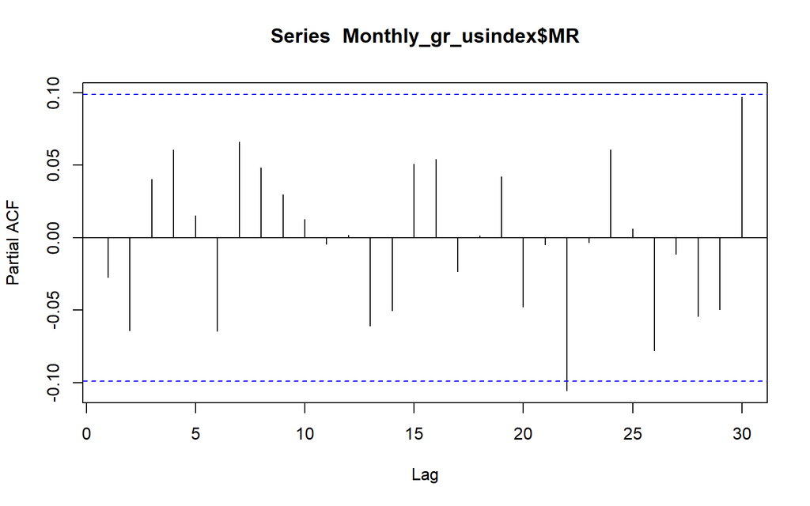

```r
pacf_MR <- pacf(Monthly_gr_usindex$MR, lag = 30)
```

```r
autocorrelation_MR
```

```
##
## Autocorrelations of series 'Monthly_gr_usindex$MR', by lag
##
##      0      1      2      3      4      5      6      7      8      9     10
##  1.000 -0.027 -0.063  0.044  0.062  0.006 -0.070  0.073  0.056  0.014  0.004
##     11     12     13     14     15     16     17     18     19     20
##  0.004  0.014 -0.065 -0.047  0.065  0.055 -0.039 -0.004  0.063 -0.047
```

```r
pacf_MR
```

```
##
## Partial autocorrelations of series 'Monthly_gr_usindex$MR', by lag
##
##      1      2      3      4      5      6      7      8      9     10     11
## -0.027 -0.064  0.040  0.061  0.015 -0.064  0.066  0.048  0.030  0.013 -0.004
##     12     13     14     15     16     17     18     19     20     21     22
##  0.002 -0.061 -0.050  0.051  0.054 -0.023  0.001  0.042 -0.048 -0.005 -0.106
##     23     24     25     26     27     28     29     30
## -0.003  0.061  0.006 -0.078 -0.011 -0.054 -0.049  0.097
```

> On obtient cette fois ci un modèle ARMA(22,0)